# Where are the 43,010 wrong-sign ER training estimates?

Site concentration, stream setting, geography, and Appling confidence assessments

2026-10-30

# 1 Question and definitions

The archived Maavara ER notebook converts negative StreamMetabolizer ER estimates to **positive respiration magnitudes** by multiplying the response by −1. It retains all training rows. I call a row *wrong-sign* when its **raw** `ER > 0`; it becomes a negative training target after that sign flip. This report locates those rows. It does **not** refit either model or prescribe an exclusion rule.

Appling and colleagues describe raw `ER > 0.5` g O₂ m⁻² d⁻¹ as biologically unrealistic while treating estimates within ±0.5 as difficult to distinguish from zero. Their release provides model-level Low/Medium/High confidence assessments based on several diagnostics, including wrong-sign frequency. Those assessments are guidance, not a row-level validity decision. [Appling et al. 2018, Scientific Data](https://pmc.ncbi.nlm.nih.gov/articles/PMC6289110/); [USGS data release](https://doi.org/10.5066/F70864KX).

The training file has 490,358 rows from 355 monitoring sites. 43,010 rows (8.8%) have raw positive ER; 34,112 exceed +0.5. The median positive raw ER is 1.91 g O₂ m⁻² d⁻¹.

# 2 Are a few sites responsible?

```r
site_rank <- copy(site)[order(-wrong)]
site_rank[, rank := seq_len(.N)]
site_rank[, cumulative_wrong_share := cumsum(wrong) / sum(wrong)]
top10_share <- sum(site_rank$wrong[1:10]) / sum(site_rank$wrong)
top20_share <- sum(site_rank$wrong[1:20]) / sum(site_rank$wrong)
site_metrics <- data.table(
  measure = c("Sites with any wrong-sign estimate", "Sites with ≥10% wrong-sign estimates",
              "Sites with ≥50% wrong-sign estimates", "Sites with all rows wrong-sign",
              "Share of wrong-sign rows from top 10 sites",
              "Share of wrong-sign rows from top 20 sites"),
  value = c(fmt(sum(site$wrong > 0)), fmt(sum(site$wrong_pct >= 10)),
            fmt(sum(site$wrong_pct >= 50)), fmt(sum(site$wrong == site$n)),
            percent(top10_share, accuracy = .1), percent(top20_share, accuracy = .1)))
kable(site_metrics, caption = "Site concentration")
```

Site concentration

| measure | value |
| --- | --- |
| Sites with any wrong-sign estimate | 318 |
| Sites with ≥10% wrong-sign estimates | 84 |
| Sites with ≥50% wrong-sign estimates | 16 |
| Sites with all rows wrong-sign | 2 |
| Share of wrong-sign rows from top 10 sites | 28.3% |
| Share of wrong-sign rows from top 20 sites | 43.3% |

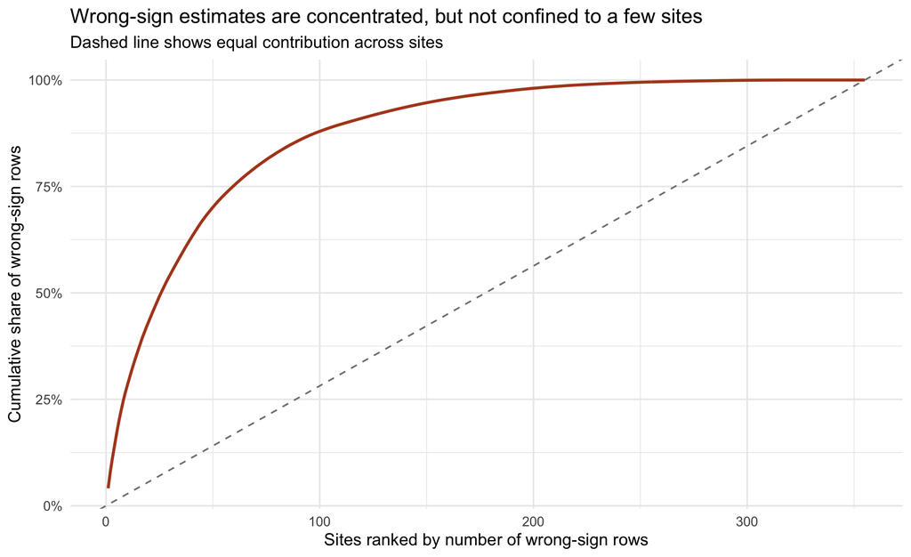

```r
ggplot(site_rank, aes(rank, cumulative_wrong_share)) +
  geom_line(linewidth = 1, color = "#b04721") +
  geom_abline(slope = 1/nrow(site_rank), intercept = 0, linetype = "dashed",
              color = "grey50") +
  scale_y_continuous(labels = percent_format()) +
  labs(x = "Sites ranked by number of wrong-sign rows", y = "Cumulative share of wrong-sign rows",
       title = "Wrong-sign estimates are concentrated, but not confined to a few sites",
       subtitle = "Dashed line shows equal contribution across sites")
```

Wrong-sign estimates occur at 318 of 355 training sites. The ten largest contributors account for 28.3% of wrong-sign rows, leaving most spread across other sites. Site counts reflect unequal time-series lengths, so the fraction within each site is also important. Two sites have no nonpositive ER training rows; removing all raw-positive ER would remove those sites entirely.

# 3 Does Appling’s confidence classification isolate them?

```r
confidence <- x[, .(training_rows = .N, wrong_rows = sum(wrong_sign),
                    clearly_wrong_rows = sum(clearly_wrong_sign),
                    sites = uniqueN(site_name)), by = site_min_confidence]
confidence[, `:=`(wrong_pct = 100 * wrong_rows / training_rows,
                  share_of_all_wrong = 100 * wrong_rows / sum(wrong_rows))]
setorder(confidence, site_min_confidence)
kable(confidence, digits = 1,
      caption = "Training rows by the lowest confidence assigned to any model at each site")
```

Training rows by the lowest confidence assigned to any model at each site

| site_min_confidence | training_rows | wrong_rows | clearly_wrong_rows | sites | wrong_pct | share_of_all_wrong |
| --- | --- | --- | --- | --- | --- | --- |
| H | 357834 | 15258 | 9951 | 245 | 4.3 | 35.5 |
| M | 66648 | 13577 | 11507 | 48 | 20.4 | 31.6 |
| L | 65876 | 14175 | 12654 | 62 | 21.5 | 33.0 |

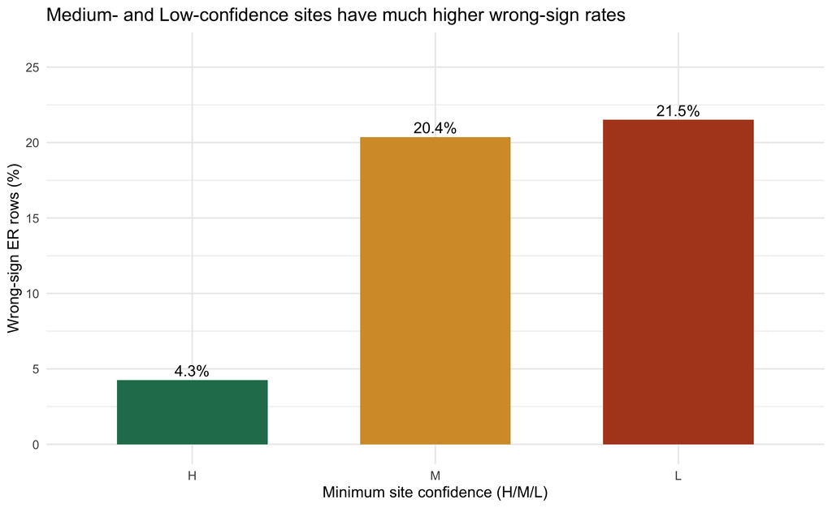

```r
ggplot(confidence, aes(site_min_confidence, wrong_pct, fill = site_min_confidence)) +
  geom_col(width = .62, show.legend = FALSE) +
  geom_text(aes(label = sprintf("%.1f%%", wrong_pct)), vjust = -.35) +
  scale_y_continuous(limits = c(0, 26), breaks = seq(0, 25, 5)) +
  scale_fill_manual(values = c(H = "#247c5b", M = "#d49b32", L = "#b04721")) +
  labs(x = "Minimum site confidence (H/M/L)", y = "Wrong-sign ER rows (%)",
       title = "Medium- and Low-confidence sites have much higher wrong-sign rates")
```

All 355 training sites match Appling’s diagnostics. The release has 433 models for 356 sites; 70 training sites have multiple models. The training CSV identifies site and date but **not which model/resolution generated each daily estimate**. This report therefore uses the release’s *minimum site confidence* as a conservative site-level descriptor. It does not assign an individual model’s H/M/L label to each training row. `ER.Rhat` and `ER.n_eff` in the training file are parameter diagnostics and cannot substitute for the full model assessment.

```r
positive <- x[wrong_sign == TRUE]
interval_table <- data.table(
  category = c("0 < raw ER ≤ 0.5", "Raw ER > 0.5; interval overlaps zero",
               "Raw ER > 0.5; interval entirely positive"),
  rows = c(sum(positive$ER <= .5),
           sum(positive$ER > .5 & positive$ER.lower <= 0),
           sum(positive$ER > .5 & positive$ER.lower > 0)))
interval_table[, share := 100 * rows / sum(rows)]
kable(interval_table, digits = 1,
      caption = "How far from zero are the raw-positive ER estimates?")
```

How far from zero are the raw-positive ER estimates?

| category | rows | share |
| --- | --- | --- |
| 0 < raw ER ≤ 0.5 | 8898 | 20.7 |
| Raw ER > 0.5; interval overlaps zero | 9290 | 21.6 |
| Raw ER > 0.5; interval entirely positive | 24822 | 57.7 |

# 4 Are they spread across stream sizes and discharge?

```r
make_bins <- function(dat, variable, label) {
  breaks <- unique(as.numeric(quantile(dat[[variable]], probs = seq(0, 1, .1),
                                      na.rm = TRUE)))
  tmp <- dat[!is.na(get(variable)), .(value = get(variable), wrong_sign)]
  tmp[, bin := cut(value, breaks = breaks, include.lowest = TRUE)]
  tmp[, .(rows = .N, wrong_rows = sum(wrong_sign),
          median_value = median(value), wrong_pct = 100 * mean(wrong_sign)),
      by = bin][, variable := label][]
}
size_bins <- make_bins(x, "uparea", "Upstream area (km²)")
flow_bins <- make_bins(x, "discharge", "Discharge (m³/s)")
bins <- rbindlist(list(size_bins, flow_bins), use.names = TRUE)
kable(bins[, .(variable, bin, rows, wrong_rows, wrong_pct)], digits = 1,
      caption = "Wrong-sign prevalence by approximately equal-row source-data bins")
```

Wrong-sign prevalence by approximately equal-row source-data bins

| variable | bin | rows | wrong_rows | wrong_pct |
| --- | --- | --- | --- | --- |
| Upstream area (km²) | [25.2,77.2] | 54002 | 2196 | 4.1 |
| Upstream area (km²) | (244,452] | 48091 | 5093 | 10.6 |
| Upstream area (km²) | (1.75e+04,2.96e+06] | 48718 | 4383 | 9.0 |
| Upstream area (km²) | (140,244] | 50328 | 4829 | 9.6 |
| Upstream area (km²) | (452,1.05e+03] | 50737 | 6151 | 12.1 |
| Upstream area (km²) | (77.2,140] | 44797 | 1130 | 2.5 |
| Upstream area (km²) | (1.05e+03,2.11e+03] | 48621 | 7115 | 14.6 |
| Upstream area (km²) | (2.11e+03,3.56e+03] | 47273 | 4901 | 10.4 |
| Upstream area (km²) | (6.54e+03,1.75e+04] | 48754 | 3647 | 7.5 |
| Upstream area (km²) | (3.56e+03,6.54e+03] | 49037 | 3565 | 7.3 |
| Discharge (m³/s) | (0.349,0.794] | 49024 | 2100 | 4.3 |
| Discharge (m³/s) | (0.115,0.349] | 49046 | 1872 | 3.8 |
| Discharge (m³/s) | [0.000283,0.115] | 49045 | 815 | 1.7 |
| Discharge (m³/s) | (0.794,1.76] | 49030 | 3287 | 6.7 |
| Discharge (m³/s) | (1.76,3.46] | 49035 | 3677 | 7.5 |
| Discharge (m³/s) | (3.46,7.25] | 49037 | 4949 | 10.1 |
| Discharge (m³/s) | (7.25,18.4] | 49033 | 7142 | 14.6 |
| Discharge (m³/s) | (89,3.78e+04] | 49035 | 6902 | 14.1 |
| Discharge (m³/s) | (35.4,89] | 49036 | 6080 | 12.4 |
| Discharge (m³/s) | (18.4,35.4] | 49037 | 6186 | 12.6 |

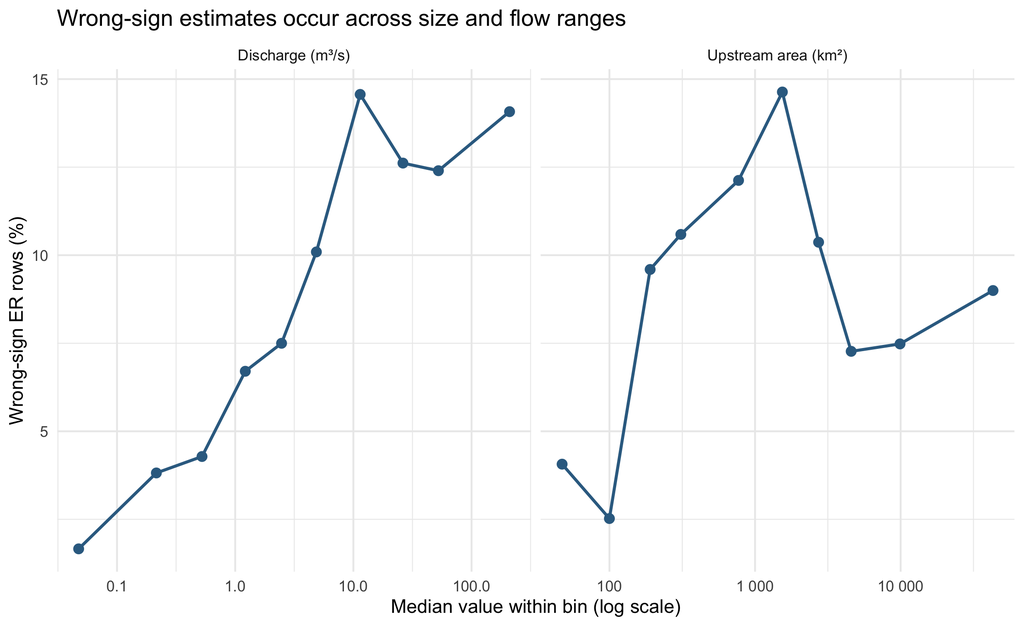

```r
ggplot(bins, aes(median_value, wrong_pct)) +
  geom_line(color = "#346c91", linewidth = .9) +
  geom_point(color = "#346c91", size = 2.5) +
  scale_x_log10(labels = label_number()) +
  facet_wrap(~variable, scales = "free_x") +
  labs(x = "Median value within bin (log scale)", y = "Wrong-sign ER rows (%)",
       title = "Wrong-sign estimates occur across size and flow ranges")
```

Raw-positive ER rows have median upstream area 1293 km² and discharge 14.21 m³/s, compared with 972 km² and 2.98 m³/s for the other rows. They occur in every displayed size and discharge bin. A simple sign-based removal would shift the training distribution toward smaller streams and lower flows.

# 5 Where are the sites?

```r
geography <- x[, .(training_rows = .N, wrong_rows = sum(wrong_sign),
                   sites = uniqueN(site_name)), by = region]
geography[, wrong_pct := 100 * wrong_rows / training_rows]
kable(geography, digits = 1,
      caption = "Broad longitude bands; boundaries are descriptive, not ecoregions")
```

Broad longitude bands; boundaries are descriptive, not ecoregions

| region | training_rows | wrong_rows | sites | wrong_pct |
| --- | --- | --- | --- | --- |
| East (>90°W) | 311250 | 22717 | 226 | 7.3 |
| Central (105–90°W) | 121125 | 6897 | 84 | 5.7 |
| West (<105°W) | 57983 | 13396 | 45 | 23.1 |

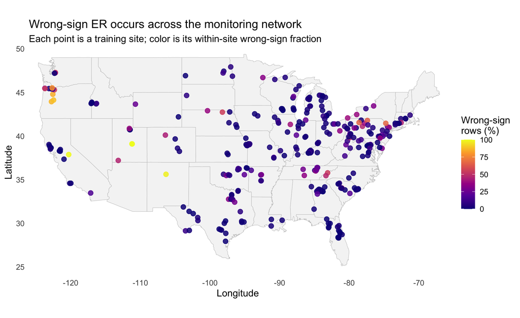

```r
states <- ggplot2::map_data("state")
ggplot() +
  geom_polygon(data = states, aes(long, lat, group = group), fill = "grey96",
               color = "grey75", linewidth = .18) +
  geom_point(data = site, aes(lon_source, lat_source, color = wrong_pct),
             size = 2.5, alpha = .85) +
  scale_color_viridis_c(option = "C", name = "Wrong-sign\nrows (%)", limits = c(0, 100)) +
  coord_quickmap(xlim = c(-126, -66), ylim = c(24, 50), expand = FALSE) +
  labs(x = "Longitude", y = "Latitude",
       title = "Wrong-sign ER occurs across the monitoring network",
       subtitle = "Each point is a training site; color is its within-site wrong-sign fraction") +
  theme(panel.grid = element_blank())
```

Western sites (`<105°W`) have a higher row-weighted wrong-sign fraction than the central or eastern bands, but the phenomenon is geographically widespread. Site sampling is uneven, and these longitude bands are not causal regions.

# 6 Season and representativeness if rows were removed

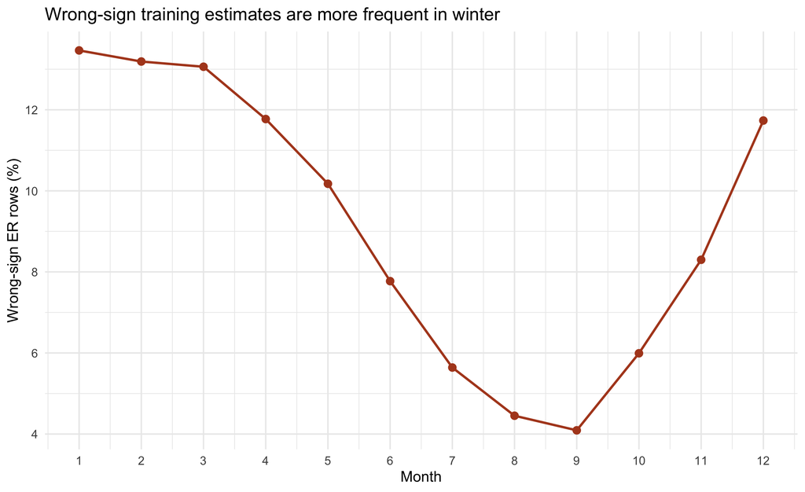

```r
season <- x[, .(training_rows = .N, wrong_rows = sum(wrong_sign)), by = month]
season[, wrong_pct := 100 * wrong_rows / training_rows]
ggplot(season, aes(month, wrong_pct)) +
  geom_line(color = "#b04721", linewidth = .9) +
  geom_point(color = "#b04721", size = 2.5) +
  scale_x_continuous(breaks = 1:12) +
  labs(x = "Month", y = "Wrong-sign ER rows (%)",
       title = "Wrong-sign training estimates are more frequent in winter")
```

Dropping all `ER > 0` training rows would remove 8.8% of training records and all records from 2 sites. It would also disproportionately remove western and winter observations and observations from higher-discharge settings. Dropping only `ER > 0.5` would remove 34,112 records (7.0%), still with uneven support. Neither rule has been applied; these are **support calculations**, not held-out model evaluations.

# 7 Answer to the proposed decision

The 43,010 rows are **not confined to a few problematic sites**. They occur at 318 of 355 training sites and across the mapped regions, upstream-area bins, and discharge bins. At the same time, they are **not evenly distributed**: the top 10 sites contribute about 28%, western sites have much higher prevalence, and Medium/Low minimum-confidence sites have roughly five times the wrong-sign rate of High minimum-confidence sites. High-confidence sites still contribute over 15,000 wrong-sign rows. Removing them would change training support and erase two sites, so it should be treated as a substantive modeling choice rather than harmless cleaning.

The most defensible next analysis is a **pre-specified sensitivity design**, pending research-team approval: compare no exclusion, a documented near-zero allowance (e.g., the source paper’s ±0.5 interpretation), and any confidence-informed rule using the *same* train/test records and predictor sets. Report retained site/day and predictor support, held-out skill by season and size, wrong-sign network predictions, and downstream 07/10/11 outcomes. This report makes no such refit.

# 8 Source and join notes

- Maavara training table: `data/raw/dryad_data/appling_data_06202024.csv` and archived `random_forest_CONUS_ER.ipynb`.
- Appling source files downloaded from the [USGS release](https://doi.org/10.5066/F70864KX) and saved in `reports/no_uparea_migration/step1_er_training_distribution/source_data/`. The report joins training `site_name` to site and diagnostic `site` identifiers; all 355 training sites match. `config.zip` confirms model configurations but does not provide a daily row-to-model key. Exact download links and hashes are in `source_data/PROVENANCE.md`.
- Appling assessments are site/model diagnostics, not independent validation of each daily ER estimate. Site minimum confidence is intentionally conservative and may label a date from one model by a different model’s lowest rating at the same site.
- Figures use raw training rows; repeated dates within sites are not independent observations. Site-level counts and fractions are shown separately to avoid interpreting a long monitoring record as many independent sites.